# Analysis of Ford GoBike System Data

### by Rohith Sowmithra

### Introduction

> Bay Area Bike Share is a company that provides on-demand bike rentals for customers in San Francisco, Redwood City, Palo Alto, Mountain View, and San Jose. Users can unlock bikes from a variety of stations throughout each city, and return them to any station within the same city. Users pay for the service either through a yearly subscription or by purchasing 3-day or 24-hour passes. Users can make an unlimited number of trips, with trips under thirty minutes in length having no additional charge; longer trips will incur overtime fees. The source data (Ford GoBike System Data) is available at : https://www.fordgobike.com/system-data. The above mentioned Data Set focuses on information with regard to the individual rides undertaken in a bike-sharing system expanded over the greater San Francisco Bay Area.

### Preliminary Wrangling

This document explores the Ford GoBike's system data for public. It contains information about 18,63,721 bike rides for FY2018.

## Gather Data

> Here, we gather data by downloading zip files from the source, then extract the zip files and combine them into a single file which can be used for analysis. We'll only download data pertaining to FY2018.

```python
# location where all the datset files are available for download in zip format
index_url = "https://s3.amazonaws.com/fordgobike-data/"

cur_directory = getcwd()

makedirs("data")

filepath = cur_directory + '/data/'

start_time = time.time()

# logic to download the csv datasets for 2018 year
for months in range(1,13):
    month = str(months).zfill(2)

    # format a url to make a download link
    dataset_url = index_url + "2018" + month + "-fordgobike-tripdata.csv.zip"

    # make a request to download a zip file particular to a month
    response = requests.get(dataset_url)

    # ZipFile is to open a zip file and BytesIO returns a readable and writeable view of the contents;
    unzipped_file = ZipFile(BytesIO(response.content))

    # places the downloaded zip file into folder data
    unzipped_file.extractall(filepath)

end_time = time.time()

elapsed_time = end_time - start_time

elapsed_time_str = time.strftime("%H:%M:%S", time.gmtime(elapsed_time))

print(f"Time taken to download all zip files is {elapsed_time_str}")
```

```
Time taken to download all zip files is 00:01:06
```

**Average Duration of the trips**

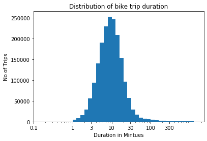

```python
# now apply log transformation on 'duration_min' column and re-visualize the histogram

bin_edges = 10 ** np.arange(0, 3.15+0.1, 0.1)
ticks =  [ 0.1 , 1 , 3, 10, 30, 100, 300]
labels = ['{}'.format(v) for v in ticks]
sb.distplot(df_copy['duration_min'], bins = bin_edges, kde = False, hist_kws = {'alpha' : 1})
plt.title('Distribution of bike trip duration')
plt.xlabel('Duration in Mintues')
plt.ylabel('No of Trips')
plt.xscale('log')
plt.xticks(ticks, labels);
```

**Gender-wise usage of bike platform**

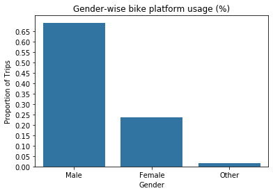

```python
df_copy.member_gender.value_counts()

# get proportion taken by most common group for derivation
n_points = df_copy.shape[0]
max_count = df_copy['member_gender'].value_counts().max()
max_prop = max_count / n_points

# generate tick mark locations and names
tick_props = np.arange(0, max_prop, 0.05)
tick_names = ['{:0.2f}'.format(v) for v in tick_props]

# create the plot
base_color = sb.color_palette()[0]
sb.countplot(data = df_copy, x = 'member_gender', color = base_color);
plt.title('Gender-wise bike platform usage (%)');
plt.xlabel('Gender');
plt.yticks(tick_props * n_points, tick_names);
plt.ylabel('Proportion of Trips');
```

**Bike sharing platform user's Age distribution**

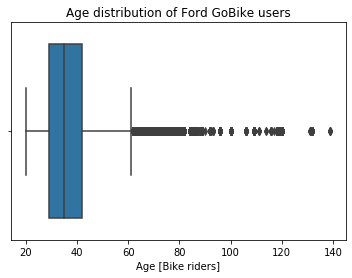

```python
sb.boxplot(data=df_copy, x='member_age', orient='h');
plt.title("Age distribution of Ford GoBike users");
plt.xlabel("Age [Bike riders]");
```

**Usertype distribution**

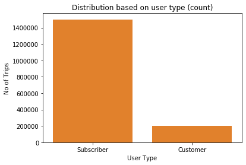

```python
base_color = sb.color_palette()[1]
sb.countplot(data=df_copy, x='user_type', color=base_color);
plt.title("Distribution based on user type (count)");
plt.xlabel("User Type");
plt.ylabel("No of Trips");
```

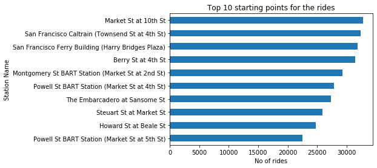

```python
top10_start_points = df_copy.start_station_name.value_counts()[1:11].sort_values()
base_color = sb.color_palette()[0]
top10_start_points.plot(kind = 'barh', color=base_color)
plt.title('Top 10 starting points for the rides')
plt.xlabel('No of rides')
plt.ylabel('Station Name');
```

**Average trip duration with respect to seasons**

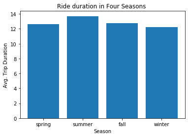

```python
# categorize months into seasons and draw bar plot
spring = df_copy.query('start_month in ["3" , "4" , "5"]').duration_min.mean()
summer = df_copy.query('start_month in ["6" , "7" , "8"]').duration_min.mean()
fall = df_copy.query('start_month in ["9" , "10" , "11"]').duration_min.mean()
winter = df_copy.query('start_month in ["12" , "1" , "2"]').duration_min.mean()

# plot the bar diagram
plt.bar(['spring','summer','fall','winter'],[spring , summer , fall , winter])
plt.title('Ride duration in Four Seasons ')
plt.xlabel('Season')
plt.ylabel('Avg. Trip Duration');
```

**Hourly usage of bike sharing system per user_type**

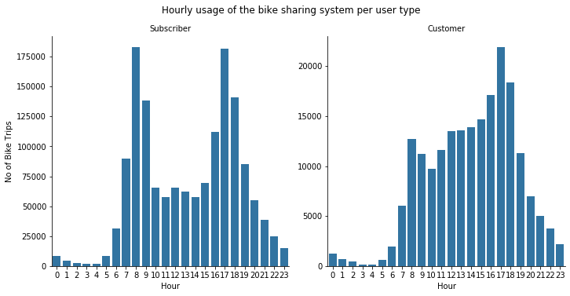

```python
# hourly usege of the bike sharing system per user type
base_color = sb.color_palette()[0]
g = sb.catplot(data=df_copy, x='start_hour', col="user_type", kind='count', sharey = False,
            color = base_color);
g.set_axis_labels("Hour", "No of Bike Trips")
g.set_titles("{col_name}")
g.fig.suptitle('Hourly usage of the bike sharing system per user type', y=1.04);
```

**Trip duration (min) per user_type**

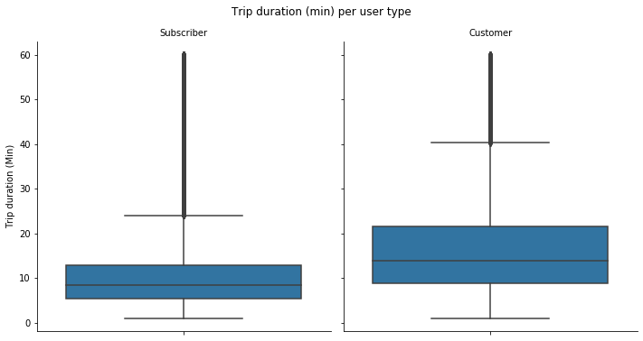

```python
# boxplot for duration (min) distribution per user type
data = df_copy.query('duration_min < 60')
base_color = sb.color_palette()[0]
g = sb.catplot(data=data, y='duration_min', col="user_type", kind='box',
            color = base_color)
g.set_titles(col_template = '{col_name}')
g.set_axis_labels("", "Trip duration (Min)")
g.fig.suptitle('Trip duration (min) per user type', y=1.04);
```

**Hourly usage during weekdays per user type**

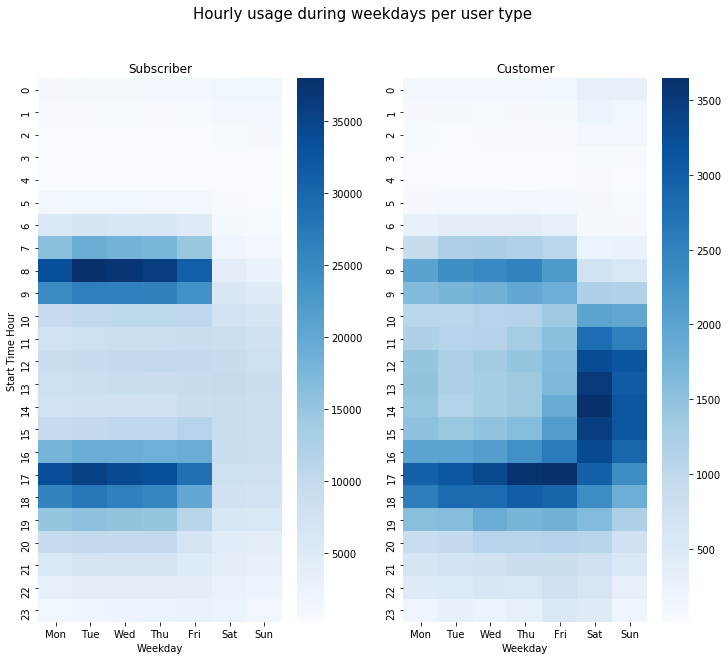

```python
# set the weekday order
wdays = pd.api.types.CategoricalDtype(ordered = True, categories = ['Mon','Tue','Wed','Thu','Fri','Sat', 'Sun'])

df_copy['start_weekday'] = df_copy['start_weekday'].astype(wdays)

# plotting visualizations

plt.figure(figsize = (12,10))
plt.suptitle("Hourly usage during weekdays per user type", fontsize=15)

# plot a heatmap for a subscriber
plt.subplot(1,2,1)
df_subscriber = df_copy.query('user_type == "Subscriber"').groupby(['start_hour', 'start_weekday'])['bike_id'].size().reset_index()
df_subscriber = df_subscriber.pivot(index='start_hour', columns='start_weekday', values='bike_id')
sb.heatmap(df_subscriber, cmap='Blues');
plt.title("Subscriber", y=1.02);
plt.xlabel('Weekday');
plt.ylabel('Start Time Hour');

# plot a heatmap for a customer
plt.subplot(1,2,2)
df_customer = df_copy.query('user_type == "Customer"').groupby(['start_hour', 'start_weekday'])['bike_id'].size().reset_index()
df_customer = df_customer.pivot(index='start_hour', columns='start_weekday', values='bike_id')
sb.heatmap(df_customer, cmap='Blues');
plt.title("Customer", y=1.02);
plt.xlabel('Weekday');
plt.ylabel('');
```

**Trip duration per usertype and gender**

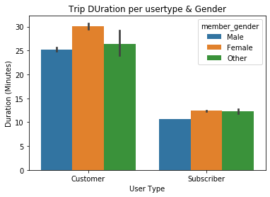

```python
sb.barplot(data=df_copy, x='user_type', y='duration_min', hue='member_gender', order=df_copy.user_type.value_counts(ascending=True).index);
plt.title("Trip DUration per usertype & Gender");
plt.xlabel('User Type');
plt.ylabel('Duration (Minutes)');
```

**No of Bike Trips per User type and Gender**

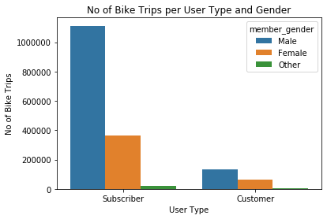

```python
# plot a bar chart below
sb.countplot(data=df_copy, x="user_type", hue="member_gender", order=df_copy.user_type.value_counts().index);
plt.xlabel('User Type');
plt.ylabel('No of Bike Trips');
plt.title("No of Bike Trips per User Type and Gender");
```